# Predicting diseases in cattle herds

Andreas Joergensen, Cathrine Olsen, Louise Christoffersen & Mette Moeller

8-1-2021

```r
library(readr)
library(tidyverse)
library(magrittr)
library(GGally)
library(tidymodels)
library(mlbench)
library(vip)
library(ranger)
library(ggpubr)
library(themis)
library(naniar)
library(ggplot2)
library(ggpubr) #For mixing multiple plots together
```

Loading the data.

```r
data <- read_csv("https://raw.githubusercontent.com/andreasbj77/SDS/main/Project/Cows.csv")
```

```r
data %>% glimpse()
```

```
Rows: 10,663
Columns: 24
$ HerdNumber         <dbl> 3, 3, 3, 1, 1, 1, 1, 1, 1, 1, 1, 1, 1, 2, 2, 2, 2, 2, 2, 2, 2, 2, 2, 2, 2, 2, 2, 2, 2, 2, 2, 2,...
$ Race               <chr> "Danish Holstein", "Danish Holstein", "Danish Holstein", "Danish Holstein", "Danish Holstein", ...
$ Disease            <chr> "Tyk has", "Tyk has", "Tyk has", "Tyk has", "Tyk has", "Tyk has", "Tyk has", "Tyk has", "Tyk ha...
$ Huld               <dbl> 3.50, 3.50, NA, NA, 4.00, 3.75, 3.50, 3.50, 3.75, 4.00, 3.75, 3.25, 3.75, NA, 3.75, 2.25, 2.50,...
$ Hasetrykning       <dbl> NA, NA, NA, NA, NA, NA, NA, NA, NA, NA, NA, NA, NA, NA, NA, NA, NA, NA, NA, NA, NA, NA, NA, NA,...
$ Andre_trykninger   <dbl> NA, NA, NA, NA, NA, NA, NA, NA, NA, NA, NA, NA, NA, NA, NA, NA, NA, NA, NA, NA, NA, NA, NA, NA,...
$ Halthed            <dbl> NA, NA, NA, NA, NA, NA, NA, NA, NA, NA, NA, NA, NA, NA, NA, NA, NA, NA, NA, NA, NA, NA, NA, NA,...
$ Hud_Haarlag        <dbl> NA, NA, NA, NA, NA, NA, NA, NA, NA, NA, NA, NA, NA, NA, NA, NA, NA, NA, NA, NA, NA, NA, NA, NA,...
$ Hygiejne_yver      <dbl> NA, NA, NA, NA, NA, NA, NA, NA, NA, NA, NA, NA, NA, NA, NA, NA, NA, NA, NA, NA, NA, NA, NA, NA,...
$ Hygiejne_haser     <dbl> NA, NA, NA, NA, NA, NA, NA, NA, NA, NA, NA, NA, NA, NA, NA, NA, NA, NA, NA, NA, NA, NA, NA, NA,...
$ Flugtafstand       <dbl> NA, NA, NA, NA, NA, NA, NA, NA, NA, NA, NA, NA, NA, NA, NA, NA, NA, NA, NA, NA, NA, NA, NA, NA,...
$ Boer               <dbl> 4, 2, NA, NA, NA, 0, 0, 4, NA, NA, 1, 4, 4, NA, NA, 5, 6, 0, 0, 3, 2, NA, 2, 1, 1, 0, 8, NA, NA...
$ Skede              <dbl> 0, 0, NA, NA, NA, 0, 0, 0, NA, NA, 0, 0, 0, NA, NA, 0, 0, 0, 0, 0, 0, NA, 0, 0, 0, 0, 1, NA, NA...
$ Goedning           <dbl> 5, 6, NA, NA, NA, 5, 5, 5, NA, NA, 5, 6, 6, NA, NA, 6, 5, 7, 5, 5, 5, NA, 7, 5, 5, 5, 6, NA, NA...
$ Ketonstof_urin     <dbl> 1, 1, NA, NA, NA, 2, 1, 6, NA, NA, 2, 1, 1, NA, NA, 2, 1, 1, 1, 1, 1, NA, 1, 1, 1, 1, 1, NA, NA...
$ CMT_min_1_kirtel   <dbl> NA, NA, NA, NA, NA, NA, NA, NA, NA, NA, NA, NA, NA, NA, NA, NA, NA, NA, NA, NA, NA, NA, NA, NA,...
$ Rejseadfaerd       <dbl> NA, NA, NA, NA, NA, NA, NA, NA, NA, NA, NA, NA, NA, NA, NA, NA, NA, NA, NA, NA, NA, NA, NA, NA,...
$ LactationNumber    <dbl> 1, 1, 2, 4, 4, 5, 4, 4, 3, 2, 2, 2, 2, 4, 5, 5, 5, 5, 5, 5, 4, 3, 4, 5, 5, 5, 4, 3, 2, 2, 3, 3,...
$ Calving_month      <dbl> 1, 0, 0, 0, 0, 0, 0, 1, 0, 1, 0, 0, 0, 0, 0, 1, 0, 0, 0, 0, 0, 0, 0, 1, 1, 1, 1, 0, 0, 0, 1, 0,...
$ InseminationNumber <dbl> 0, 1, 1, 1, 1, 1, 3, 1, 1, 1, 3, 2, 1, 4, 2, 2, 1, 1, 1, 1, 1, 1, 3, 1, 1, 1, 1, 1, 2, 2, 1, 2,...
$ Insemination_month <dbl> 0, 1, 0, 0, 0, 0, 0, 0, 0, 0, 1, 0, 0, 0, 0, 0, 0, 1, 0, 0, 0, 0, 0, 0, 0, 0, 0, 0, 0, 0, 0, 1,...
$ MilkYield          <dbl> 21.2, 32.3, 24.1, 0.0, 41.0, 63.0, 69.6, 0.0, 31.1, 0.0, 53.3, 45.3, 45.5, 28.4, 22.4, 0.0, 52....
$ Change_milkyield   <dbl> -13.3, 0.0, 24.1, 0.0, -0.8, 1.5, 69.6, -21.2, -6.1, 0.0, -6.1, -1.8, -7.0, 0.0, 22.4, -27.8, 5...
$ DiseaseCategory    <chr> "Hoof and limb disorders", "Hoof and limb disorders", "Hoof and limb disorders", "Hoof and limb...
```

```r
data %>%
  count(DiseaseCategory)
```

| DiseaseCategory | n |
| --- | --- |
| Healthy | 3543 |
| Hoof and limb disorders | 875 |
| Metabolic disorders | 300 |
| Reproduction disorders | 693 |
| Udder disorders | 5252 |

After loading the data set some variables are recoded as factors.

```r
data %<>%
  mutate(HerdNumber = HerdNumber %>% as.factor()) %>%
  mutate(Race = Race %>% as.factor()) %>%
  mutate(Insemination_month = Insemination_month %>% as.factor()) %>%
  mutate(Calving_month = Calving_month %>% as.factor())
```

# EDA

Looking at the distribution of the newly created variable, *DiseaseCategory*.

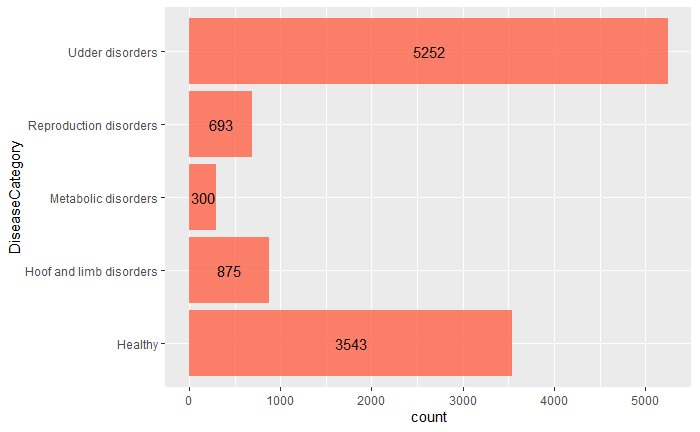

```r
data %>%
  ggplot(aes(x = DiseaseCategory)) +
  geom_bar(fill ="tomato", alpha = 0.8) +
  geom_text(aes(label=..count..), stat = "count", position=position_stack(0.5)) +
  coord_flip()
```

## Herd and race

Looking at the distribution of the *HerdNumber* variable.

```r
 data %>%
  count(HerdNumber) %>%
  mutate(pct = (n/sum(n) * 100)%>% round(3)) %>%
  mutate(HerdNumber = HerdNumber %>% as.factor())
```

| HerdNumber | n | pct |
| --- | --- | --- |
| 1 | 1984 | 18.606 |
| 2 | 5565 | 52.190 |
| 3 | 3114 | 29.204 |

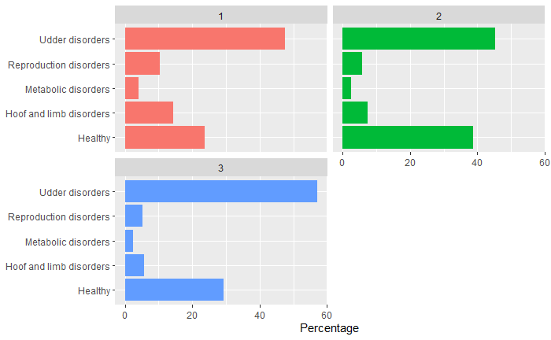

```r
data %>%
  count(DiseaseCategory, HerdNumber) %>%
  group_by(HerdNumber) %>%
  mutate(pct = (n/sum(n))%>% round(3)) %>%
  mutate(DiseaseCategory = DiseaseCategory %>% as.factor()) %>%
  mutate(ypos = cumsum(pct)- 0.5*pct ) %>%
  ungroup() %>%
  mutate(pct = pct *100) %>%
  ggplot(aes(x = DiseaseCategory, y = pct, fill = HerdNumber)) +
  geom_col(show.legend = FALSE) +
  labs(x = NULL, y = "Percentage")  + facet_wrap(~HerdNumber, ncol = 2) +
  coord_flip()
```

```r
data%>%
  count(Race) %>%
  mutate(pct = (n/sum(n)*100) %>%round(3))
```

| Race | n | pct |
| --- | --- | --- |
| Danish Holstein | 8239 | 77.267 |
| Danish Jersey | 80 | 0.750 |
| Danish red and white Cattle | 2221 | 20.829 |
| Red Danish Dairy Breed | 123 | 1.154 |

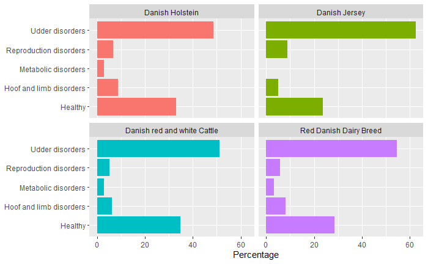

```r
data %>%
  count(DiseaseCategory, Race) %>%
  group_by(Race) %>%
  mutate(pct = (n/sum(n))%>% round(3)) %>%
  mutate(DiseaseCategory = DiseaseCategory %>% as.factor()) %>%
  mutate(ypos = cumsum(pct)- 0.5*pct ) %>%
  ungroup() %>%
  mutate(pct = pct *100) %>%
  ggplot(aes(x = DiseaseCategory, y = pct, fill = Race)) +
  geom_col(show.legend = FALSE) +
  labs(x = NULL, y = "Percentage")  + facet_wrap(~Race, ncol = 2) +
  coord_flip()
```

```r
data %>%
  count(HerdNumber, Race) %>%
  group_by(HerdNumber) %>%
  mutate(pct = (n / sum(n, na.rm = TRUE)*100) %>% round(3) ) %>%
  select(-n) %>%
  pivot_wider(names_from = Race, values_from = pct)
```

| HerdNumber | Danish Holstein | Danish red and white Cattle | Red Danish Dairy Breed | Danish Jersey |
| --- | --- | --- | --- | --- |
| 1 | 99.546 | 0.454 | NA | NA |
| 2 | 78.473 | 21.473 | 0.054 | NA |
| 3 | 60.918 | 32.659 | 3.854 | 2.569 |

## Insemination

Looking at the distribution of the *Insemination_month* variable.

```r
 data %>%
  count(Insemination_month) %>%
  mutate(pct = (n/sum(n))*100 %>% round(3)) %>%
  mutate(Insemination_month = Insemination_month %>% as.factor())
```

| Insemination_month | n | pct |
| --- | --- | --- |
| 0 | 10043 | 94.185501 |
| 1 | 620 | 5.814499 |

```r
data %>%
  count(InseminationNumber)
```

| InseminationNumber | n |
| --- | --- |
| 0 | 11 |
| 1 | 5013 |
| 2 | 2965 |
| 3 | 1287 |
| 4 | 762 |
| 5 | 300 |
| 6 | 184 |
| 7 | 94 |
| 8 | 20 |
| 9 | 5 |

[output cut: 3 more lines]

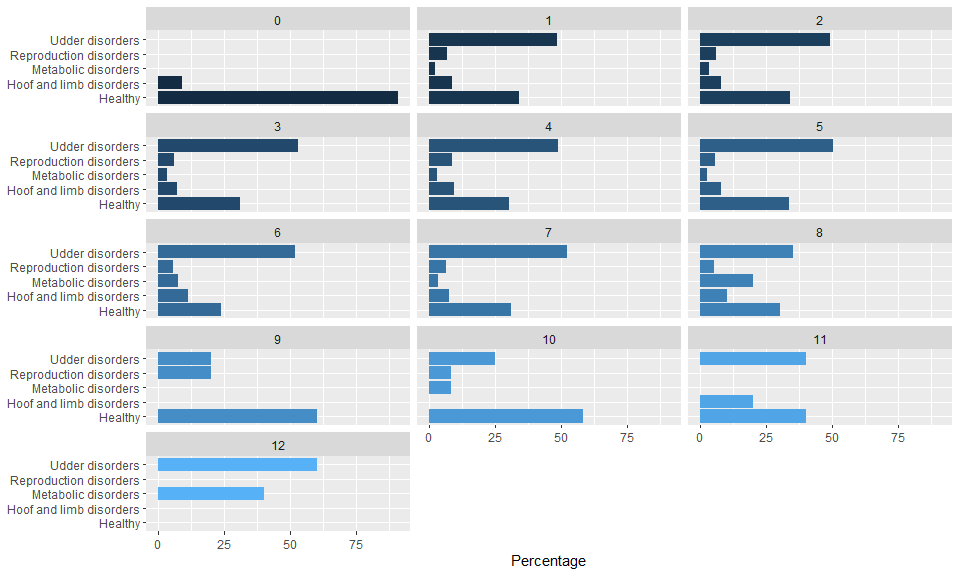

```r
data %>%
  group_by(InseminationNumber) %>%
  count(DiseaseCategory, InseminationNumber) %>%
  mutate(pct = (n/sum(n))) %>%
  mutate(DiseaseCategory = DiseaseCategory %>% as.factor()) %>%
  ungroup() %>%
  mutate(pct = pct *100) %>%
    ggplot(aes(x = DiseaseCategory, y = pct, fill = InseminationNumber)) +
    geom_col(show.legend = FALSE) +
    labs(x = NULL, y = "Percentage")  + facet_wrap(~InseminationNumber, ncol = 3) +
    coord_flip()
```

```r
data %>%
  group_by(InseminationNumber) %>%
  count(DiseaseCategory, InseminationNumber) %>%
  mutate(pct = (n/sum(n)*100) %>% round(3)) %>%
  mutate(DiseaseCategory = DiseaseCategory %>% as.factor()) %>%
  ungroup() %>%
  arrange(DiseaseCategory)
```

| InseminationNumber | DiseaseCategory | n | pct |
| --- | --- | --- | --- |
| 0 | Healthy | 10 | 90.909 |
| 1 | Healthy | 1703 | 33.972 |
| 2 | Healthy | 1007 | 33.963 |
| 3 | Healthy | 400 | 31.080 |
| 4 | Healthy | 231 | 30.315 |
| 5 | Healthy | 101 | 33.667 |
| 6 | Healthy | 44 | 23.913 |
| 7 | Healthy | 29 | 30.851 |
| 8 | Healthy | 6 | 30.000 |
| 9 | Healthy | 3 | 60.000 |

[output cut: 44 more lines]

## Lactation and calving

Looking at the distribution of the *Calving_month* variable.

```r
data %>%
  count(Calving_month) %>%
  mutate(pct = (n/sum(n))*100 %>% round(3)) %>%
  mutate(Calving_month = Calving_month %>% as.factor())
```

| Calving_month | n | pct |
| --- | --- | --- |
| 0 | 9625 | 90.265404 |
| 1 | 1038 | 9.734596 |

```r
data %>%
  count(LactationNumber)
```

| LactationNumber | n |
| --- | --- |
| 0 | 9 |
| 1 | 3451 |
| 2 | 2832 |
| 3 | 2180 |
| 4 | 1310 |
| 5 | 596 |
| 6 | 203 |
| 7 | 53 |
| 8 | 24 |
| 9 | 5 |

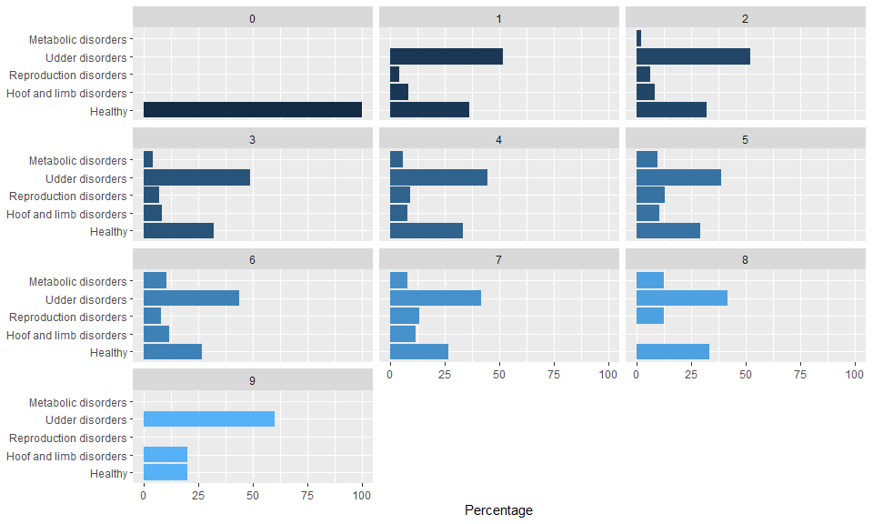

```r
data %>%
  group_by(LactationNumber) %>%
  count(DiseaseCategory, LactationNumber) %>%
  mutate(pct = (n/sum(n))) %>%
  mutate(DiseaseCategory = DiseaseCategory %>% as.factor()) %>%
  ungroup() %>%
  mutate(pct = pct *100) %>%
  ggplot(aes(x = DiseaseCategory, y = pct, fill = LactationNumber)) +
  geom_col(show.legend = FALSE) +
  labs(x = NULL, y = "Percentage")  + facet_wrap(~LactationNumber, ncol = 3) +
  coord_flip()
```

```r
data %>%
  group_by(LactationNumber) %>%
  count(DiseaseCategory, LactationNumber) %>%
  mutate(pct = (n/sum(n)*100) %>% round(3)) %>%
  mutate(DiseaseCategory = DiseaseCategory %>% as.factor()) %>%
  ungroup() %>%

  arrange(DiseaseCategory)
```

| LactationNumber | DiseaseCategory | n | pct |
| --- | --- | --- | --- |
| 0 | Healthy | 9 | 100.000 |
| 1 | Healthy | 1253 | 36.308 |
| 2 | Healthy | 901 | 31.815 |
| 3 | Healthy | 696 | 31.927 |
| 4 | Healthy | 433 | 33.053 |
| 5 | Healthy | 174 | 29.195 |
| 6 | Healthy | 54 | 26.601 |
| 7 | Healthy | 14 | 26.415 |
| 8 | Healthy | 8 | 33.333 |
| 9 | Healthy | 1 | 20.000 |

[output cut: 32 more lines]

## Milk yield

```r
data %>%
  mutate(MilkYield = MilkYield %>% round(0)) %>%
  count(MilkYield) %>%
  mutate(pct = (n/sum(n)) %>% round(4)) %>%
    ungroup() %>%
 mutate(pct = pct *100) %>%
  filter(MilkYield == 0)
```

| MilkYield | n | pct |
| --- | --- | --- |
| 0 | 1140 | 10.69 |

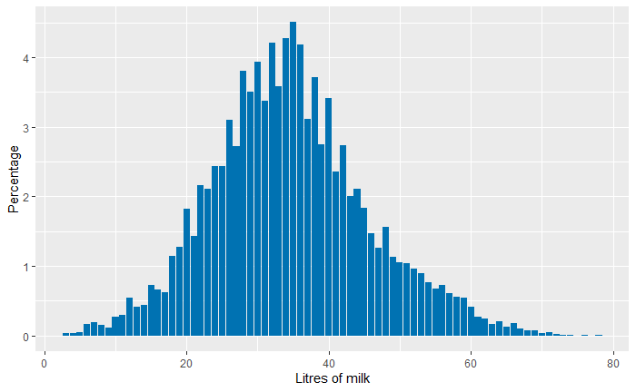

```r
data %>%
 filter(MilkYield != 0) %>%
  mutate(MilkYield = MilkYield %>% round(0)) %>%
  count(MilkYield) %>%
  mutate(pct = (n/sum(n)) %>% round(4)) %>%
    ungroup() %>%
 mutate(pct = pct *100) %>%
 ggplot(aes(x = MilkYield, y = pct,)) +
 geom_col(show.legend = FALSE, fill = "#0072B2") +
 labs(x = "Litres of milk", y = "Percentage")
```

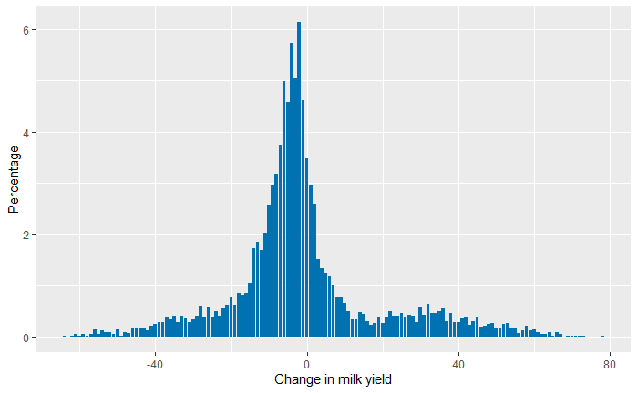

```r
data %>%
  filter(Change_milkyield !=0) %>%
  mutate(Change_milkyield = Change_milkyield %>% round(0)) %>%
  count(Change_milkyield) %>%
  mutate(pct = (n/sum(n)) %>% round(4)) %>%
    ungroup() %>%
 mutate(pct = pct *100) %>%
 ggplot(aes(x = Change_milkyield, y = pct,)) +
 geom_col(show.legend = FALSE, fill = "#0072B2") +
 labs(x = "Change in milk yield", y = "Percentage")
```

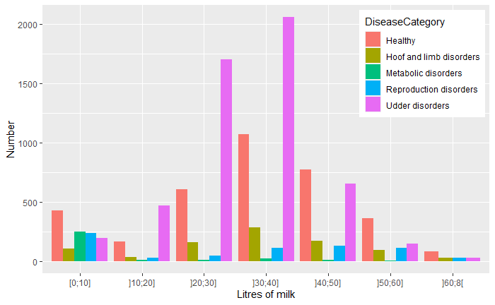

```r
plot <- data %>%
  filter(!(MilkYield == "NA")) %>%
  mutate(MilkYield = MilkYield %>% as.numeric()) %>%
  mutate(MilkYield1 = ifelse(MilkYield > 60 , "]60;∞[",
                            ifelse(MilkYield<= 60 & MilkYield > 50, "]50;60]",
                            ifelse(MilkYield <= 50 & MilkYield > 40, "]40;50]",
                            ifelse(MilkYield <= 40 & MilkYield > 30, "]30;40]",
                            ifelse(MilkYield <= 30 & MilkYield > 20, "]20;30]",
                            ifelse(MilkYield <= 20 & MilkYield > 10, "]10;20]",
                            ifelse(MilkYield <= 10 & MilkYield >= 0, "[0;10]", 0)))))))) %>%
            mutate(MilkYield1 = MilkYield1 %>% as.factor)  %>%
     group_by(DiseaseCategory) %>%
    add_count(MilkYield1) %>%
  distinct(MilkYield1, n, .keep_all = TRUE)

plot %>%
 ggplot(aes(x = MilkYield1, y = n, fill = DiseaseCategory)) +
geom_col(show.legend = TRUE, position = position_dodge()) +
  theme(legend.position = c(.85,.78))  +
 labs(x = "Litres of milk", y = "Number")
```

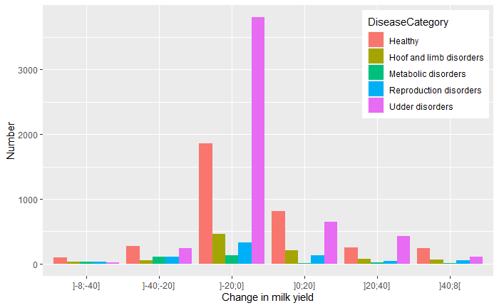

```r
plot1 <- data %>%
  mutate(Change_milkyield = Change_milkyield %>% as.numeric()) %>%
  mutate(Change_milkyield1 = ifelse(Change_milkyield > 40 , 6,
                            ifelse(Change_milkyield <= 40 & Change_milkyield > 20, 5,
                            ifelse(Change_milkyield <= 20 & Change_milkyield > 0, 4,
                            ifelse(Change_milkyield <= 0 & Change_milkyield > -20, 3,
                            ifelse(Change_milkyield <= -20 & Change_milkyield > -40, 2,
                            ifelse(Change_milkyield <= -40 , 1, 0))))))) %>%
  group_by(DiseaseCategory) %>%
  add_count(Change_milkyield1) %>%
  distinct(Change_milkyield1, n, .keep_all = TRUE)


plot1$Change_milkyield1 <- factor(as.numeric(plot1$Change_milkyield1), #Next the factor command assigns names to the intervals of grades
          levels = c(1, 2, 3,  4, 5, 6),
          labels = c("]-∞;-40]",  "]-40;-20]", "]-20;0]", "]0;20]", "]20;40]","]40;∞["))




plot1 %>%
 ggplot(aes(x = Change_milkyield1, y = n, fill = DiseaseCategory)) +
 geom_col(show.legend = TRUE, position = position_dodge()) +
   theme(legend.position = c(.85,.78))  +
 labs(x = "Change in milk yield", y = "Number")
```

Removing unneeded data.

```r
rm(calvingpie, calvingpie_plot, herdpie, insimpie, insimpie_plot, plot, plot1)
```

## NAs

For all disease types.

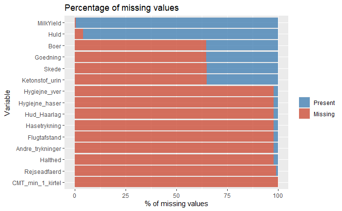

```r
missing.values <- data %>%
  gather(key = "key", value = "val") %>%
  mutate(isna = is.na(val)) %>%
  group_by(key) %>%
  mutate(total = n()) %>%
  group_by(key, total, isna) %>%
  summarise(num.isna = n()) %>%
  mutate(pct = num.isna / total * 100)


levels <-
    (missing.values  %>% filter(isna == T) %>% arrange(desc(pct)))$key

percentage.plot <- missing.values %>%
      ggplot() +
        geom_bar(aes(x = reorder(key, desc(pct)),
                     y = pct, fill=isna),
                 stat = 'identity', alpha=0.8) +
      scale_x_discrete(limits = levels) +
      scale_fill_manual(name = "",
                        values = c('steelblue', 'tomato3'), labels = c("Present", "Missing")) +
      coord_flip() +
      labs(title = "Percentage of missing values", x =
             'Variable', y = "% of missing values")

percentage.plot
```

```r
rm(missing.values, percentage.plot, levels)
```

### NA’s for DiseaseCategory

Creating a temporary data set containing clinical parameters and DiseaseCategory.

```r
clin <- data[,4:17]
clin %<>% add_column(data[,24])
```

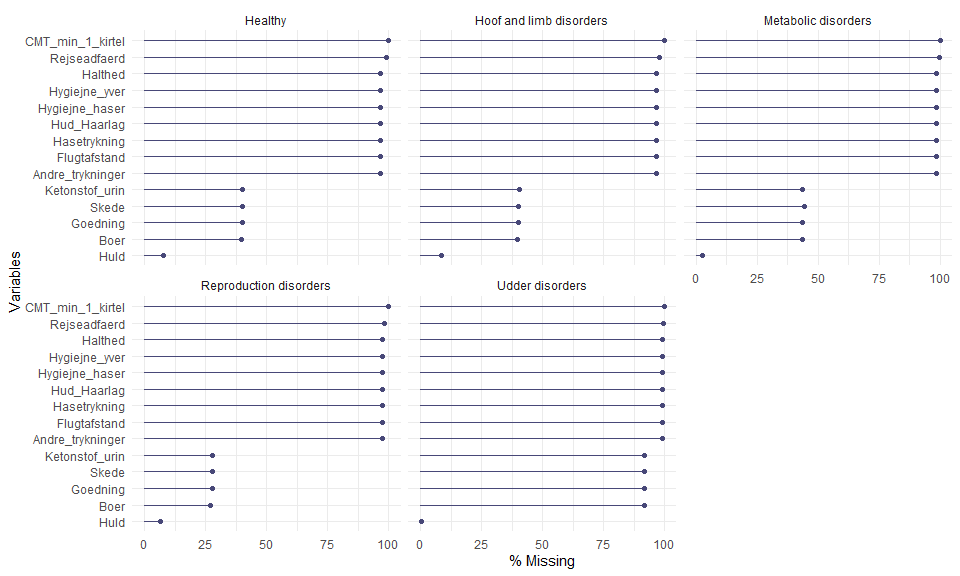

```r
NA_clin <- gg_miss_var(clin, facet = DiseaseCategory, show_pct = TRUE)
NA_clin
```

```r
data %>%
  group_by(DiseaseCategory) %>%
  add_count(DiseaseCategory) %>%
  mutate(Na_keton = ((sum(is.na(Ketonstof_urin))/n)*100) %>% round(1)) %>%
  mutate(Na_skede = ((sum(is.na(Skede))/n)*100) %>% round(1)) %>%
  mutate(Na_goedning = ((sum(is.na(Goedning))/n)*100) %>% round(1)) %>%
  mutate(Na_boer = ((sum(is.na(Boer))/n)*100) %>% round(1)) %>%
  mutate(Na_huld = ((sum(is.na(Huld))/n)*100) %>% round(1)) %>%
  distinct(DiseaseCategory, n, .keep_all = TRUE) %>%
  mutate(Na_keton = paste(Na_keton, "%")) %>%
  mutate(Na_skede = paste(Na_skede, "%")) %>%
  mutate(Na_goedning = paste(Na_goedning, "%")) %>%
  mutate(Na_boer = paste(Na_boer, "%"))%>%
  mutate(Na_huld = paste(Na_huld, "%"))%>%
  arrange(desc(n)) %>%
  select(DiseaseCategory, Na_keton, Na_skede, Na_goedning, Na_boer, Na_huld)
```

| DiseaseCategory | Na_keton | Na_skede | Na_goedning | Na_boer | Na_huld |
| --- | --- | --- | --- | --- | --- |
| Udder disorders | 91.9 % | 91.8 % | 91.7 % | 91.7 % | 0.6 % |
| Healthy | 40.2 % | 40.2 % | 40.1 % | 39.6 % | 7.8 % |
| Hoof and limb disorders | 40.7 % | 40.2 % | 40.1 % | 39.8 % | 8.7 % |
| Reproduction disorders | 27.7 % | 27.7 % | 27.7 % | 27.1 % | 6.6 % |
| Metabolic disorders | 43.7 % | 44.3 % | 43.7 % | 43.3 % | 2.3 % |

```r
rm(clin, NA_clin, NA_plot)
```

# Supervised Machine Learning

After loading the data set some variables are recoded as factors.

```r
data %<>%
  select(-c(CMT_min_1_kirtel, Rejseadfaerd, Halthed, Hygiejne_yver, Hygiejne_haser, Hud_Haarlag, Hasetrykning, Andre_trykninger, Flugtafstand))
```

```r
data %<>%
  mutate(Huld = Huld %>% as.factor()) %>%
  mutate(Boer = Boer %>% as.factor()) %>%
  mutate(Skede = Skede %>% as.factor()) %>%
  mutate(Goedning = Goedning %>% as.factor()) %>%
  mutate(Ketonstof_urin = Ketonstof_urin %>% as.factor()) %>%
  mutate(DiseaseCategory = DiseaseCategory %>% as.factor())
```

```r
data %>% glimpse()
```

```
Rows: 10,663
Columns: 15
$ HerdNumber         <fct> 3, 3, 3, 1, 1, 1, 1, 1, 1, 1, 1, 1, 1, 2, 2, 2, 2, 2, 2, 2, 2, 2, 2, 2, 2, 2, 2, 2, 2, 2, 2, 2,...
$ Race               <fct> Danish Holstein, Danish Holstein, Danish Holstein, Danish Holstein, Danish Holstein, Danish Hol...
$ Disease            <chr> "Tyk has", "Tyk has", "Tyk has", "Tyk has", "Tyk has", "Tyk has", "Tyk has", "Tyk has", "Tyk ha...
$ Huld               <fct> 3.5, 3.5, NA, NA, 4, 3.75, 3.5, 3.5, 3.75, 4, 3.75, 3.25, 3.75, NA, 3.75, 2.25, 2.5, 3.5, 3.5, ...
$ Boer               <fct> 4, 2, NA, NA, NA, 0, 0, 4, NA, NA, 1, 4, 4, NA, NA, 5, 6, 0, 0, 3, 2, NA, 2, 1, 1, 0, 8, NA, NA...
$ Skede              <fct> 0, 0, NA, NA, NA, 0, 0, 0, NA, NA, 0, 0, 0, NA, NA, 0, 0, 0, 0, 0, 0, NA, 0, 0, 0, 0, 1, NA, NA...
$ Goedning           <fct> 5, 6, NA, NA, NA, 5, 5, 5, NA, NA, 5, 6, 6, NA, NA, 6, 5, 7, 5, 5, 5, NA, 7, 5, 5, 5, 6, NA, NA...
$ Ketonstof_urin     <fct> 1, 1, NA, NA, NA, 2, 1, 6, NA, NA, 2, 1, 1, NA, NA, 2, 1, 1, 1, 1, 1, NA, 1, 1, 1, 1, 1, NA, NA...
$ LactationNumber    <dbl> 1, 1, 2, 4, 4, 5, 4, 4, 3, 2, 2, 2, 2, 4, 5, 5, 5, 5, 5, 5, 4, 3, 4, 5, 5, 5, 4, 3, 2, 2, 3, 3,...
$ Calving_month      <fct> 1, 0, 0, 0, 0, 0, 0, 1, 0, 1, 0, 0, 0, 0, 0, 1, 0, 0, 0, 0, 0, 0, 0, 1, 1, 1, 1, 0, 0, 0, 1, 0,...
$ InseminationNumber <dbl> 0, 1, 1, 1, 1, 1, 3, 1, 1, 1, 3, 2, 1, 4, 2, 2, 1, 1, 1, 1, 1, 1, 3, 1, 1, 1, 1, 1, 2, 2, 1, 2,...
$ Insemination_month <fct> 0, 1, 0, 0, 0, 0, 0, 0, 0, 0, 1, 0, 0, 0, 0, 0, 0, 1, 0, 0, 0, 0, 0, 0, 0, 0, 0, 0, 0, 0, 0, 1,...
$ MilkYield          <dbl> 21.2, 32.3, 24.1, 0.0, 41.0, 63.0, 69.6, 0.0, 31.1, 0.0, 53.3, 45.3, 45.5, 28.4, 22.4, 0.0, 52....
$ Change_milkyield   <dbl> -13.3, 0.0, 24.1, 0.0, -0.8, 1.5, 69.6, -21.2, -6.1, 0.0, -6.1, -1.8, -7.0, 0.0, 22.4, -27.8, 5...
$ DiseaseCategory    <fct> Hoof and limb disorders, Hoof and limb disorders, Hoof and limb disorders, Hoof and limb disord...
```

## Data sets for modeling

Three different ways of categorizing is used and training and test splits are created for each data set.

**5 categories**

```r
data_five <- data %>%
  select(-Disease) %>%
  rename(y = DiseaseCategory)
```

```r
set.seed(1337)
data_split_five <- data_five %>% initial_split(prop = 0.8, strata = y)

data_train_five <- data_split_five %>% training()
data_test_five <- data_split_five %>% testing()
```

**3 categories**

```r
data_three <- data %>%
  select(-Disease) %>%
  mutate(DiseaseCategory = ifelse(DiseaseCategory == "Healthy", "Healthy",
                  ifelse(DiseaseCategory == "Udder disorders", "Udder disorders", "Other")) %>% as.factor()) %>%
  rename(y = DiseaseCategory)
```

```r
set.seed(1337)
data_split_three <- data_three %>% initial_split(prop = 0.8, strata = y)

data_train_three <- data_split_three %>% training()
data_test_three <- data_split_three %>% testing()
```

**2 categories**

```r
data_bi <- data %>%
  select(-Disease) %>%
  mutate(DiseaseCategory = ifelse(DiseaseCategory == "Healthy", "Healthy", "Sick") %>% as.factor()) %>%
  rename(y = DiseaseCategory)
```

```r
set.seed(1337)
data_split_bi <- data_bi %>% initial_split(prop = 0.8, strata = y)

data_train_bi <- data_split_bi %>% training()
data_test_bi <- data_split_bi %>% testing()
```

```r
glimpse(data_five)
```

```
Rows: 10,663
Columns: 14
$ HerdNumber         <fct> 3, 3, 3, 1, 1, 1, 1, 1, 1, 1, 1, 1, 1, 2, 2, 2, 2, 2, 2, 2, 2, 2, 2, 2, 2, 2, 2, 2, 2, 2, 2, 2,...
$ Race               <fct> Danish Holstein, Danish Holstein, Danish Holstein, Danish Holstein, Danish Holstein, Danish Hol...
$ Huld               <fct> 3.5, 3.5, NA, NA, 4, 3.75, 3.5, 3.5, 3.75, 4, 3.75, 3.25, 3.75, NA, 3.75, 2.25, 2.5, 3.5, 3.5, ...
$ Boer               <fct> 4, 2, NA, NA, NA, 0, 0, 4, NA, NA, 1, 4, 4, NA, NA, 5, 6, 0, 0, 3, 2, NA, 2, 1, 1, 0, 8, NA, NA...
$ Skede              <fct> 0, 0, NA, NA, NA, 0, 0, 0, NA, NA, 0, 0, 0, NA, NA, 0, 0, 0, 0, 0, 0, NA, 0, 0, 0, 0, 1, NA, NA...
$ Goedning           <fct> 5, 6, NA, NA, NA, 5, 5, 5, NA, NA, 5, 6, 6, NA, NA, 6, 5, 7, 5, 5, 5, NA, 7, 5, 5, 5, 6, NA, NA...
$ Ketonstof_urin     <fct> 1, 1, NA, NA, NA, 2, 1, 6, NA, NA, 2, 1, 1, NA, NA, 2, 1, 1, 1, 1, 1, NA, 1, 1, 1, 1, 1, NA, NA...
$ LactationNumber    <dbl> 1, 1, 2, 4, 4, 5, 4, 4, 3, 2, 2, 2, 2, 4, 5, 5, 5, 5, 5, 5, 4, 3, 4, 5, 5, 5, 4, 3, 2, 2, 3, 3,...
$ Calving_month      <fct> 1, 0, 0, 0, 0, 0, 0, 1, 0, 1, 0, 0, 0, 0, 0, 1, 0, 0, 0, 0, 0, 0, 0, 1, 1, 1, 1, 0, 0, 0, 1, 0,...
$ InseminationNumber <dbl> 0, 1, 1, 1, 1, 1, 3, 1, 1, 1, 3, 2, 1, 4, 2, 2, 1, 1, 1, 1, 1, 1, 3, 1, 1, 1, 1, 1, 2, 2, 1, 2,...
$ Insemination_month <fct> 0, 1, 0, 0, 0, 0, 0, 0, 0, 0, 1, 0, 0, 0, 0, 0, 0, 1, 0, 0, 0, 0, 0, 0, 0, 0, 0, 0, 0, 0, 0, 1,...
$ MilkYield          <dbl> 21.2, 32.3, 24.1, 0.0, 41.0, 63.0, 69.6, 0.0, 31.1, 0.0, 53.3, 45.3, 45.5, 28.4, 22.4, 0.0, 52....
$ Change_milkyield   <dbl> -13.3, 0.0, 24.1, 0.0, -0.8, 1.5, 69.6, -21.2, -6.1, 0.0, -6.1, -1.8, -7.0, 0.0, 22.4, -27.8, 5...
$ y                  <fct> Hoof and limb disorders, Hoof and limb disorders, Hoof and limb disorders, Hoof and limb disord...
```

## Recipies

A recipe is created for each data set where NAs are imputed using k nearest neighbor imputation, numeric variables are centered and scaled, and the data is upsampled to overcome the uneven classes.

```r
set.seed(1337)
# 5 categories
data_recipe_five <- data_train_five %>%
  recipe(y ~.) %>%
  step_upsample(y) %>%
  step_knnimpute(all_predictors()) %>%
  step_center(all_numeric()) %>%
  step_scale(all_numeric())

# 3 categories
data_recipe_three <- data_train_three %>%
  recipe(y ~.) %>%
  step_upsample(y) %>%
  step_knnimpute(all_predictors()) %>%
  step_center(all_numeric()) %>%
  step_scale(all_numeric())

# 2 categories
data_recipe_bi <- data_train_bi %>%
  recipe(y ~.) %>%
  step_upsample(y) %>%
  step_knnimpute(all_predictors()) %>%
  step_center(all_numeric()) %>%
  step_scale(all_numeric())
```

## Model creation

Two models are used for the Supervised Machine Learning part - a decision tree and a random forest model. The models are defined below.

```r
model_dt <- decision_tree(mode = 'classification',
                          cost_complexity = tune(),
                          tree_depth = tune(),
                          min_n = tune()
                          ) %>%
  set_engine('rpart')

model_rf <- rand_forest(mode = 'classification',
                        trees = 25, #number of trees choosen for the ensemble
                        mtry = tune(),
                        min_n = tune()
                        ) %>%
  set_engine('ranger', importance = 'impurity')
```

After defining the models the recipes from earlier are combined with the different models to create a workflow for each separate model.

```r
# 5 categories
workflow_general_five <- workflow() %>% #Adding recipe to the general workflow
  add_recipe(data_recipe_five)

workflow_rf_five <- workflow_general_five %>% #Adding the models to the workflow
  add_model(model_rf)

workflow_dt_five <- workflow_general_five %>%
  add_model(model_dt)

# 3 categories
workflow_general_three <- workflow() %>%
  add_recipe(data_recipe_three)

workflow_rf_three <- workflow_general_three %>%
  add_model(model_rf)

workflow_dt_three <- workflow_general_three %>%
  add_model(model_dt)

# 2 categories
workflow_general_bi <- workflow() %>%
  add_recipe(data_recipe_bi)

workflow_rf_bi <- workflow_general_bi %>%
  add_model(model_rf)

workflow_dt_bi <- workflow_general_bi %>%
  add_model(model_dt)
```

The training data is then separated into 3 folds and training is repeated 3 times for all three categorizations.

```r
set.seed(1337)
# 5 categories
data_resample_five <- data_train_five %>%
  vfold_cv(strata = y,
           v = 3,
           repeats = 3)

# 3 categories
data_resample_three <- data_train_three %>%
  vfold_cv(strata = y,
           v = 3,
           repeats = 3)

# 2 categories
data_resample_bi <- data_train_bi %>%
  vfold_cv(strata = y,
           v = 3,
           repeats = 3)
```

## Hyperparameter tuning

Since the models weren’t designed with specific parameter values, the parameters are tuned with the `tune_grid()` command for the three categorizations.

```r
set.seed(1337)
# 5 categories
tune_dt_five <-
  tune_grid(
    workflow_dt_five,
    resamples = data_resample_five,
    grid = 10
  )
```

```r
set.seed(1337)
tune_rf_five <-
  tune_grid(
    workflow_rf_five,
    resamples = data_resample_five,
    grid = 10
  )
```

```r
set.seed(1337)
# 3 categories
tune_dt_three <-
  tune_grid(
    workflow_dt_three,
    resamples = data_resample_three,
    grid = 10
  )
```

```r
set.seed(1337)
tune_rf_three <-
  tune_grid(
    workflow_rf_three,
    resamples = data_resample_three,
    grid = 10
  )
```

```r
set.seed(1337)
# 2 categories
tune_dt_bi <-
  tune_grid(
    workflow_dt_bi,
    resamples = data_resample_bi,
    grid = 10
  )
```

```r
set.seed(1337)
tune_rf_bi <-
  tune_grid(
    workflow_rf_bi,
    resamples = data_resample_five,
    grid = 10
  )
```

Since this is a classification problem the best model is chosen based on the ‘roc_auc’ metric for all the models.

```r
# 5 categories
best_param_dt_five <- tune_dt_five %>% select_best(metric = 'roc_auc')
best_param_rf_five <- tune_rf_five %>% select_best(metric = "roc_auc")

# 3 categories
best_param_dt_three <- tune_dt_three %>% select_best(metric = 'roc_auc')
best_param_rf_three <- tune_rf_three %>% select_best(metric = "roc_auc")

# 2 categories
best_param_dt_bi <- tune_dt_bi %>% select_best(metric = 'roc_auc')
best_param_rf_bi <- tune_rf_bi %>% select_best(metric = "roc_auc")
```

## Choosing the best model

After tuning the hyperparameters, the final workflows are created.

```r
# 5 categories
workflow_final_rf_five <- workflow_rf_five %>%
  finalize_workflow(parameters = best_param_rf_five) #adding the tuning to the existing workflow

workflow_final_dt_five <- workflow_dt_five %>%
  finalize_workflow(parameters = best_param_dt_five)

# 3 categories
workflow_final_rf_three <- workflow_rf_three %>%
  finalize_workflow(parameters = best_param_rf_three)

workflow_final_dt_three <- workflow_dt_three %>%
  finalize_workflow(parameters = best_param_dt_three)

# 2 categories
workflow_final_rf_bi <- workflow_rf_bi %>%
  finalize_workflow(parameters = best_param_rf_five)

workflow_final_dt_bi <- workflow_dt_bi %>%
  finalize_workflow(parameters = best_param_dt_bi)
```

The final models are fitted to the training data.

```r
set.seed(1337)
# 5 categories
fit_rf_five <- workflow_final_rf_five %>%
  fit(data_train_five)

fit_dt_five <- workflow_final_dt_five %>%
  fit(data_train_five)

# 3 categories
fit_rf_three <- workflow_final_rf_three %>%
  fit(data_train_three)

fit_dt_three <- workflow_final_dt_three %>%
  fit(data_train_three)

# 2 categories
fit_rf_bi <- workflow_final_rf_bi %>%
  fit(data_train_bi)

fit_dt_bi <- workflow_final_dt_bi %>%
  fit(data_train_bi)
```

### Comparing the models

Tables are created by comparing the predicted values to the true values to evaluate the models performance.

```r
set.seed(1337)
# 5 categories
pred_collected_five <- tibble(
  truth = data_train_five %>% pull(y) %>% as.factor(), #Takes the true values from the training data
  rf = fit_rf_five %>% predict(new_data = data_train_five) %>% pull(.pred_class), #predicting y based on the training data
  dt = fit_dt_five %>% predict(new_data = data_train_five) %>% pull(.pred_class),) %>%
  pivot_longer(cols = -truth, names_to = 'model', values_to = '.pred')

# 3 categories
pred_collected_three <- tibble(
  truth = data_train_three %>% pull(y) %>% as.factor(),
  rf = fit_rf_three %>% predict(new_data = data_train_three) %>% pull(.pred_class),
  dt = fit_dt_three %>% predict(new_data = data_train_three) %>% pull(.pred_class),) %>%
  pivot_longer(cols = -truth, names_to = 'model', values_to = '.pred')


# 2 categories
pred_collected_bi <- tibble(
  truth = data_train_bi %>% pull(y) %>% as.factor(),
  rf = fit_rf_bi %>% predict(new_data = data_train_bi) %>% pull(.pred_class),
  dt = fit_dt_bi %>% predict(new_data = data_train_bi) %>% pull(.pred_class),) %>%
  pivot_longer(cols = -truth, names_to = 'model', values_to = '.pred')
```

The accuracy of the models is calculated.

```r
# 5 categories
pred5 <- pred_collected_five %>%
  group_by(model) %>%
  accuracy(truth = truth, estimate = .pred) %>%
  select(model, .estimate) %>%
  rename("5 categories" = .estimate)

# 3 categories
pred3 <- pred_collected_three %>%
  group_by(model) %>%
  accuracy(truth = truth, estimate = .pred) %>%
  select(model, .estimate) %>%
  rename("3 categories" = .estimate) %>%
  select("3 categories")

# 5 categories
pred2 <- pred_collected_bi %>%
  group_by(model) %>%
  accuracy(truth = truth, estimate = .pred) %>%
  select(model, .estimate) %>%
  rename("2 categories" = .estimate) %>%
  select("2 categories")

cbind(pred5, pred3, pred2)
```

| model | 5 categories | 3 categories | 2 categories |
| --- | --- | --- | --- |
| dt | 0.4882194 | 0.6108767 | 0.6527192 |
| rf | 0.5971164 | 0.7443741 | 0.7058134 |

Confusion matrices for all of the models are created.

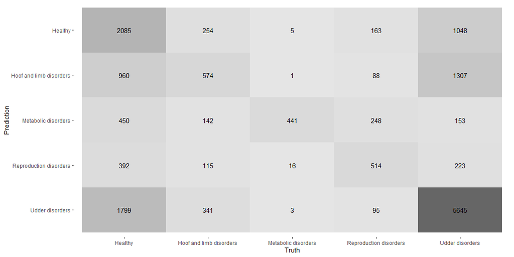

```r
# 5 categories
cm_rf_five <- pred_collected_five %>% conf_mat(truth, .pred)
heatmap5 <- cm_rf_five %>% autoplot(type = "heatmap")

# 3 categories
cm_rf_three <- pred_collected_three %>% conf_mat(truth, .pred)
heatmap3 <- cm_rf_three %>% autoplot(type = "heatmap")

# 2 categories
cm_rf_bi <- pred_collected_bi %>% conf_mat(truth, .pred)
heatmap2 <- cm_rf_bi %>% autoplot(type = "heatmap")

heatmap5
```

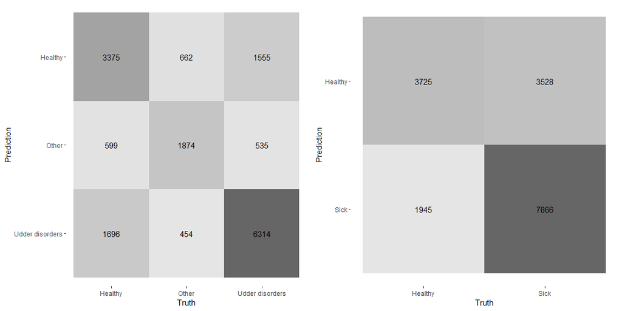

```r
ggarrange(heatmap3, heatmap2)
```

## Fitting the last models

The models are evaluated on the test set.

```r
set.seed(1337)
# 5 categories
fit_last_rf_five <- workflow_final_rf_five %>% last_fit(split = data_split_five)

# 3 categories
fit_last_rf_three <- workflow_final_rf_three %>% last_fit(split = data_split_three)

# 5 categories
fit_last_rf_bi <- workflow_final_rf_bi %>% last_fit(split = data_split_bi)
```

Plots showing variables of importance are presented for all of the models.

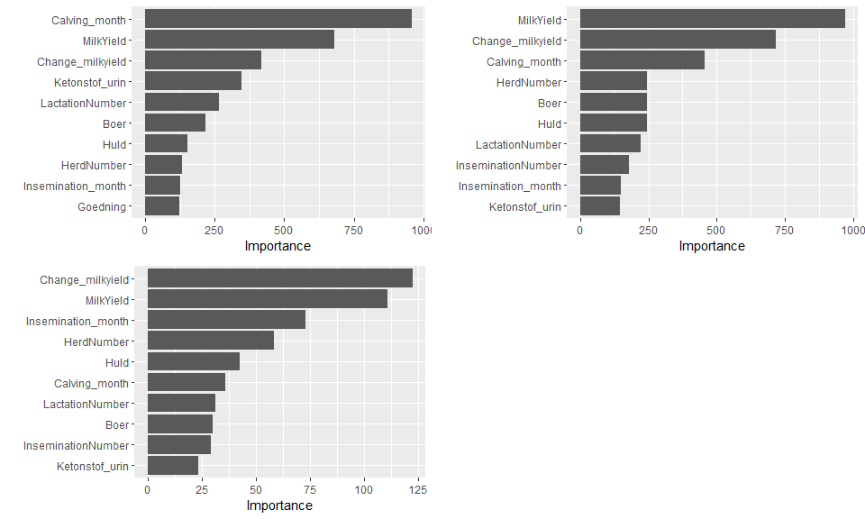

```r
# 5 categories
vip5 <- fit_last_rf_five %>%
  pluck(".workflow", 1) %>%
  pull_workflow_fit() %>%
  vip::vip(num_features = 10)

# 3 categories
vip3 <- fit_last_rf_three %>%
  pluck(".workflow", 1) %>%
  pull_workflow_fit() %>%
  vip::vip(num_features = 10)

# 2 categories
vip2 <- fit_last_rf_bi %>%
  pluck(".workflow", 1) %>%
  pull_workflow_fit() %>%
  vip::vip(num_features = 10)

ggarrange(vip5, vip3, vip2)
```

## Evaluation

The accuracy of the models performance on the test set is calculated.

```r
test_metrics5 <- fit_last_rf_five %>% collect_metrics() %>%
  rename("5 categories" = .estimate) %>%
  select(-.estimator)

test_metrics3 <- fit_last_rf_three %>% collect_metrics() %>%
    rename("3 categories" = .estimate) %>%
  select("3 categories")

test_metrics2 <- fit_last_rf_bi %>% collect_metrics() %>%
    rename("2 categories" = .estimate) %>%
  select("2 categories")

cbind(test_metrics5, test_metrics3, test_metrics2)
```

| .metric | 5 categories | 3 categories | 2 categories |
| --- | --- | --- | --- |
| accuracy | 0.5605066 | 0.6222431 | 0.6785547 |
| roc_auc | 0.8045974 | 0.7641118 | 0.7112738 |

Based on the predictions confusion matrices are presented.

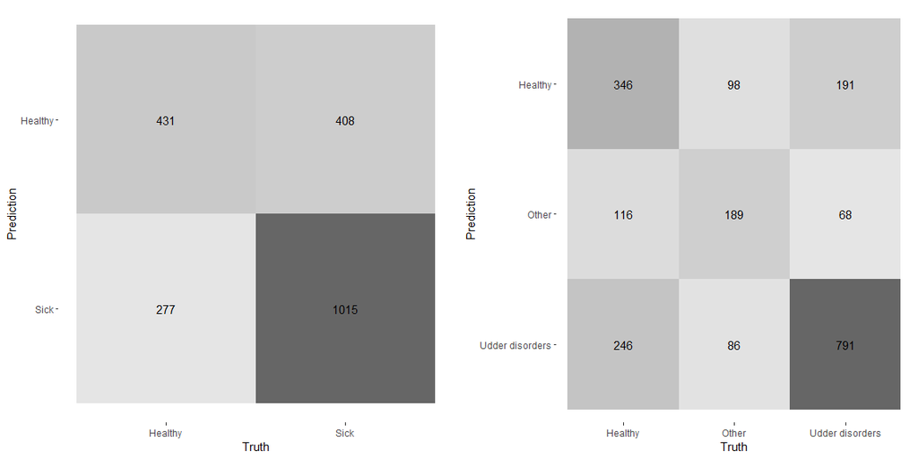

```r
# 5 categories
test_pred5 <- fit_last_rf_five %>% collect_predictions()

mat5 <- test_pred5 %>% conf_mat(y, .pred_class)
heatplot5 <- mat5 %>% autoplot(type = "heatmap")

# 3 categories
test_pred3 <- fit_last_rf_three %>% collect_predictions()

mat3 <- test_pred3 %>% conf_mat(y, .pred_class)
heatplot3 <- mat3 %>% autoplot(type = "heatmap")

# 2 categories
test_pred2 <- fit_last_rf_bi %>% collect_predictions()

mat2 <- test_pred2 %>% conf_mat(y, .pred_class)
heatplot2 <- mat2 %>% autoplot(type = "heatmap")

ggarrange(heatplot2, heatplot3)
```

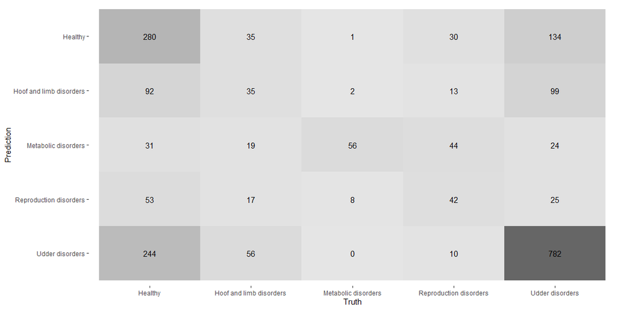

```r
heatplot5
```

Since the overall accuracy can be misleading in cases with unbalanced classes the precision for each class in each of the categorizations is calculated.

```r
cm5 <- as.matrix(mat5$table)
cm3 <- as.matrix(mat3$table)
cm2 <- as.matrix(mat2$table)
```

```r
rowsums5 = apply(cm5, 1, sum) #Number of predictions per class
colsums5 = apply(cm5, 2, sum) #Number of predictions per class
diag5 = diag(cm5) # Number of correctly classified instances per class

Precision5 = diag5/rowsums5 %>% as.table()
Sensitivity5 = diag5/colsums5 %>% as.table()

cbind(Precision5, Sensitivity5)
```

```
                        Precision5 Sensitivity5
Healthy                  0.5833333    0.4000000
Hoof and limb disorders  0.1452282    0.2160494
Metabolic disorders      0.3218391    0.8358209
Reproduction disorders   0.2896552    0.3021583
Udder disorders          0.7161172    0.7349624
```

```r
rowsums3 = apply(cm3, 1, sum)
colsums3 = apply(cm3, 2, sum) #Number of predictions per class
diag3 = diag(cm3)

Precision3 = diag3/rowsums3 %>% as.table()
Sensitivity3 = diag3/colsums3 %>% as.table()

cbind(Precision3, Sensitivity3)
```

```
                Precision3 Sensitivity3
Healthy          0.5448819    0.4887006
Other            0.5067024    0.5067024
Udder disorders  0.7043633    0.7533333
```

```r
rowsums2 = apply(cm2, 1, sum)
colsums2 = apply(cm2, 2, sum) #Number of predictions per class
diag2 = diag(cm2)

Precision2 = diag2/rowsums2 %>% as.table()
Sensitivity2 = diag2/colsums2 %>% as.table()

cbind(Precision2, Sensitivity2)
```

```
        Precision2 Sensitivity2
Healthy  0.5137068    0.6087571
Sick     0.7856037    0.7132818
```

# Neural Networks

## Data sets for modeling

Three different ways of categorizing is used and training and test splits are created for each data set.

**5 categories**

```r
data_five <- data %>%
  select(-Disease) %>%
  rename(y = DiseaseCategory)
```

```r
data_split_five <- data_five %>% initial_split(prop = 0.8, strata = y)

data_train_five <- data_split_five %>% training()
data_test_five <- data_split_five %>% testing()
```

**3 categories**

```r
data_three <- data %>%
  select(-Disease) %>%
  mutate(DiseaseCategory = ifelse(DiseaseCategory == "Healthy", "Healthy",
                  ifelse(DiseaseCategory == "Udder disorders", "Udder disorders", "Other")) %>% as.factor()) %>%
  rename(y = DiseaseCategory)
```

```r
data_split_three <- data_three %>% initial_split(prop = 0.8, strata = y)

data_train_three <- data_split_three %>% training()
data_test_three <- data_split_three %>% testing()
```

**2 categories**

```r
data_bi <- data %>%
  select(-Disease) %>%
  mutate(DiseaseCategory = ifelse(DiseaseCategory == "Healthy", "Healthy", "Sick") %>% as.factor()) %>%
  rename(y = DiseaseCategory)
```

```r
data_split_bi <- data_bi %>% initial_split(prop = 0.8, strata = y)

data_train_bi <- data_split_bi %>% training()
data_test_bi <- data_split_bi %>% testing()
```

```r
glimpse(data_five)
```

```
Rows: 10,663
Columns: 14
$ HerdNumber         <fct> 3, 3, 3, 1, 1, 1, 1, 1, 1, 1, 1, 1, 1, 2, 2, 2, 2, 2, 2, 2, 2, 2, 2, 2, 2, 2, 2, 2, 2, 2, 2, 2,...
$ Race               <fct> Danish Holstein, Danish Holstein, Danish Holstein, Danish Holstein, Danish Holstein, Danish Hol...
$ Huld               <fct> 3.5, 3.5, NA, NA, 4, 3.75, 3.5, 3.5, 3.75, 4, 3.75, 3.25, 3.75, NA, 3.75, 2.25, 2.5, 3.5, 3.5, ...
$ Boer               <fct> 4, 2, NA, NA, NA, 0, 0, 4, NA, NA, 1, 4, 4, NA, NA, 5, 6, 0, 0, 3, 2, NA, 2, 1, 1, 0, 8, NA, NA...
$ Skede              <fct> 0, 0, NA, NA, NA, 0, 0, 0, NA, NA, 0, 0, 0, NA, NA, 0, 0, 0, 0, 0, 0, NA, 0, 0, 0, 0, 1, NA, NA...
$ Goedning           <fct> 5, 6, NA, NA, NA, 5, 5, 5, NA, NA, 5, 6, 6, NA, NA, 6, 5, 7, 5, 5, 5, NA, 7, 5, 5, 5, 6, NA, NA...
$ Ketonstof_urin     <fct> 1, 1, NA, NA, NA, 2, 1, 6, NA, NA, 2, 1, 1, NA, NA, 2, 1, 1, 1, 1, 1, NA, 1, 1, 1, 1, 1, NA, NA...
$ LactationNumber    <dbl> 1, 1, 2, 4, 4, 5, 4, 4, 3, 2, 2, 2, 2, 4, 5, 5, 5, 5, 5, 5, 4, 3, 4, 5, 5, 5, 4, 3, 2, 2, 3, 3,...
$ Calving_month      <fct> 1, 0, 0, 0, 0, 0, 0, 1, 0, 1, 0, 0, 0, 0, 0, 1, 0, 0, 0, 0, 0, 0, 0, 1, 1, 1, 1, 0, 0, 0, 1, 0,...
$ InseminationNumber <dbl> 0, 1, 1, 1, 1, 1, 3, 1, 1, 1, 3, 2, 1, 4, 2, 2, 1, 1, 1, 1, 1, 1, 3, 1, 1, 1, 1, 1, 2, 2, 1, 2,...
$ Insemination_month <fct> 0, 1, 0, 0, 0, 0, 0, 0, 0, 0, 1, 0, 0, 0, 0, 0, 0, 1, 0, 0, 0, 0, 0, 0, 0, 0, 0, 0, 0, 0, 0, 1,...
$ MilkYield          <dbl> 21.2, 32.3, 24.1, 0.0, 41.0, 63.0, 69.6, 0.0, 31.1, 0.0, 53.3, 45.3, 45.5, 28.4, 22.4, 0.0, 52....
$ Change_milkyield   <dbl> -13.3, 0.0, 24.1, 0.0, -0.8, 1.5, 69.6, -21.2, -6.1, 0.0, -6.1, -1.8, -7.0, 0.0, 22.4, -27.8, 5...
$ y                  <fct> Hoof and limb disorders, Hoof and limb disorders, Hoof and limb disorders, Hoof and limb disord...
```

```r
library(keras)
```

## Recipes

```r
# 5 categories
data_recipe_DL_five <- data_train_five %>%
  recipe(y ~.) %>%
  step_knnimpute(all_predictors()) %>%
  step_center(all_numeric()) %>%
  step_scale(all_numeric()) %>%
  themis::step_upsample(y) %>%
  step_dummy(all_nominal(), one_hot = TRUE) %>%
  prep()

# 3 categories
data_recipe_DL_three <- data_train_three %>%
  recipe(y ~.) %>%
  step_knnimpute(all_predictors()) %>%
  step_center(all_numeric()) %>%
  step_scale(all_numeric()) %>%
  themis::step_upsample(y) %>%
  step_dummy(all_nominal(), one_hot = TRUE) %>%
  prep()

# 2 categories
data_recipe_DL_bi <- data_train_bi %>%
  recipe(y ~.) %>%
  step_knnimpute(all_predictors()) %>%
  step_center(all_numeric()) %>%
  step_scale(all_numeric()) %>%
  themis::step_upsample(y) %>%
  step_dummy(all_nominal(), one_hot = TRUE) %>%
  prep()
```

## Defining X and Y variables

```r
# 5 categories - train data
x_train_five <- juice(data_recipe_DL_five) %>% select(-starts_with('y')) %>% as.matrix()
y_train_five <- juice(data_recipe_DL_five) %>% select(starts_with('y')) %>% as.matrix()

# 5 categories - test data
x_test_five <- bake(data_recipe_DL_five, new_data = data_test_five) %>% select(-starts_with('y')) %>% as.matrix()
y_test_five <- bake(data_recipe_DL_five, new_data = data_test_five) %>% select(starts_with('y')) %>% as.matrix()

# 3 categories - train data
x_train_three <- juice(data_recipe_DL_three) %>% select(-starts_with('y')) %>% as.matrix()
y_train_three <- juice(data_recipe_DL_three) %>% select(starts_with('y')) %>% as.matrix()

# 3 categories - test data
x_test_three <- bake(data_recipe_DL_three, new_data = data_test_three) %>% select(-starts_with('y')) %>% as.matrix()
y_test_three <- bake(data_recipe_DL_three, new_data = data_test_three) %>% select(starts_with('y')) %>% as.matrix()

# 2 categories - train data
x_train_bi <- juice(data_recipe_DL_bi) %>% select(-starts_with('y')) %>% as.matrix()
y_train_bi <- juice(data_recipe_DL_bi) %>% select(starts_with('y')) %>% as.matrix()

# 2 categories - test data
x_test_bi <- bake(data_recipe_DL_bi, new_data = data_test_bi) %>% select(-starts_with('y')) %>% as.matrix()
y_test_bi <- bake(data_recipe_DL_bi, new_data = data_test_bi) %>% select(starts_with('y')) %>% as.matrix()
```

## Models

```r
# 5 categories
model_five <- keras_model_sequential() %>%
  layer_dense(units = 32, activation = "relu", input_shape = ncol(x_train_five)) %>%
  layer_dropout(rate = 0.2) %>%
  layer_dense(units = ncol(y_train_five), activation = "softmax")

# 3 categories
model_three <- keras_model_sequential() %>%
  layer_dense(units = 32, activation = "relu", input_shape = ncol(x_train_three)) %>%
  layer_dropout(rate = 0.2) %>%
  layer_dense(units = ncol(y_train_three), activation = "softmax")

# 2 categories
model_bi <- keras_model_sequential() %>%
  layer_dense(units = 32, activation = "relu", input_shape = ncol(x_train_bi)) %>%
  layer_dropout(rate = 0.2) %>%
  layer_dense(units = ncol(y_train_bi), activation = "sigmoid")
```

Compiling the models.

```r
# 5 categories
model_five %>% compile(
  optimizer = "adam",
  loss = "categorical_crossentropy",
  metrics = "accuracy")

# 3 categories
model_three %>% compile(
  optimizer = "adam",
  loss = "categorical_crossentropy",
  metrics = "accuracy")

# 2 categories
model_bi %>% compile(
  optimizer = "adam",
  loss = "binary_crossentropy",
  metrics = "accuracy")
```

## Fitting the models

```r
# 5 categories
history_five <- model_five %>% fit(x = x_train_five,
                               y = y_train_five,
                               epochs = 10,
                               verbose = 2,
                               batch_size = 64,
                               validation_split = 0.10)
```

```
299/299 - 0s - loss: 1.3552 - accuracy: 0.4049
299/299 - 1s - loss: 1.3552 - accuracy: 0.4049 - val_loss: 1.7037 - val_accuracy: 0.0019
299/299 - 0s - loss: 1.1938 - accuracy: 0.4716
299/299 - 1s - loss: 1.1938 - accuracy: 0.4716 - val_loss: 1.6100 - val_accuracy: 0.0198
299/299 - 0s - loss: 1.1499 - accuracy: 0.4969
299/299 - 1s - loss: 1.1499 - accuracy: 0.4969 - val_loss: 1.5784 - val_accuracy: 0.0589
299/299 - 0s - loss: 1.1224 - accuracy: 0.5137
299/299 - 1s - loss: 1.1224 - accuracy: 0.5137 - val_loss: 1.5158 - val_accuracy: 0.1013
299/299 - 0s - loss: 1.1043 - accuracy: 0.5203
299/299 - 1s - loss: 1.1043 - accuracy: 0.5203 - val_loss: 1.5443 - val_accuracy: 0.1258
299/299 - 0s - loss: 1.0887 - accuracy: 0.5291
299/299 - 1s - loss: 1.0887 - accuracy: 0.5291 - val_loss: 1.4456 - val_accuracy: 0.1875
299/299 - 0s - loss: 1.0752 - accuracy: 0.5333
299/299 - 1s - loss: 1.0752 - accuracy: 0.5333 - val_loss: 1.3737 - val_accuracy: 0.2355
299/299 - 0s - loss: 1.0626 - accuracy: 0.5420
299/299 - 1s - loss: 1.0626 - accuracy: 0.5420 - val_loss: 1.3701 - val_accuracy: 0.2223
299/299 - 0s - loss: 1.0549 - accuracy: 0.5440
299/299 - 1s - loss: 1.0549 - accuracy: 0.5440 - val_loss: 1.4630 - val_accuracy: 0.1955
299/299 - 0s - loss: 1.0423 - accuracy: 0.5473
299/299 - 1s - loss: 1.0423 - accuracy: 0.5473 - val_loss: 1.5020 - val_accuracy: 0.1550
```

```r
# 3 categories
history_three <- model_three %>% fit(x = x_train_three,
                               y = y_train_three,
                               epochs = 10,
                               verbose = 2,
                               batch_size = 64,
                               validation_split = 0.10)
```

```
178/178 - 0s - loss: 1.0246 - accuracy: 0.4640
178/178 - 1s - loss: 1.0246 - accuracy: 0.4640 - val_loss: 1.1281 - val_accuracy: 0.2205
178/178 - 0s - loss: 0.9382 - accuracy: 0.5412
178/178 - 0s - loss: 0.9382 - accuracy: 0.5412 - val_loss: 1.1273 - val_accuracy: 0.2847
178/178 - 0s - loss: 0.9171 - accuracy: 0.5639
178/178 - 0s - loss: 0.9171 - accuracy: 0.5639 - val_loss: 1.1136 - val_accuracy: 0.3117
178/178 - 0s - loss: 0.9034 - accuracy: 0.5654
178/178 - 0s - loss: 0.9034 - accuracy: 0.5654 - val_loss: 1.0622 - val_accuracy: 0.3561
178/178 - 0s - loss: 0.8932 - accuracy: 0.5746
178/178 - 0s - loss: 0.8932 - accuracy: 0.5746 - val_loss: 0.9870 - val_accuracy: 0.4496
178/178 - 0s - loss: 0.8904 - accuracy: 0.5769
178/178 - 0s - loss: 0.8904 - accuracy: 0.5769 - val_loss: 1.0178 - val_accuracy: 0.4076
178/178 - 0s - loss: 0.8805 - accuracy: 0.5728
178/178 - 0s - loss: 0.8805 - accuracy: 0.5728 - val_loss: 1.0778 - val_accuracy: 0.3450
178/178 - 0s - loss: 0.8770 - accuracy: 0.5785
178/178 - 0s - loss: 0.8770 - accuracy: 0.5785 - val_loss: 1.0339 - val_accuracy: 0.4013
178/178 - 0s - loss: 0.8734 - accuracy: 0.5848
178/178 - 0s - loss: 0.8734 - accuracy: 0.5848 - val_loss: 1.0147 - val_accuracy: 0.4274
178/178 - 0s - loss: 0.8689 - accuracy: 0.5853
178/178 - 0s - loss: 0.8689 - accuracy: 0.5853 - val_loss: 1.0911 - val_accuracy: 0.3592
```

```r
# 2 categories
history_bi <- model_bi %>% fit(x = x_train_bi,
                               y = y_train_bi,
                               epochs = 10,
                               verbose = 2,
                               batch_size = 64,
                               validation_split = 0.10)
```

```
161/161 - 0s - loss: 0.6733 - accuracy: 0.5914
161/161 - 1s - loss: 0.6733 - accuracy: 0.5914 - val_loss: 0.8231 - val_accuracy: 0.2044
161/161 - 0s - loss: 0.6447 - accuracy: 0.6271
161/161 - 0s - loss: 0.6447 - accuracy: 0.6271 - val_loss: 0.8432 - val_accuracy: 0.2281
161/161 - 0s - loss: 0.6292 - accuracy: 0.6487
161/161 - 0s - loss: 0.6292 - accuracy: 0.6487 - val_loss: 0.8864 - val_accuracy: 0.2123
161/161 - 0s - loss: 0.6238 - accuracy: 0.6540
161/161 - 0s - loss: 0.6238 - accuracy: 0.6540 - val_loss: 0.8647 - val_accuracy: 0.2281
161/161 - 0s - loss: 0.6167 - accuracy: 0.6601
161/161 - 0s - loss: 0.6167 - accuracy: 0.6601 - val_loss: 0.8106 - val_accuracy: 0.2763
161/161 - 0s - loss: 0.6091 - accuracy: 0.6725
161/161 - 0s - loss: 0.6091 - accuracy: 0.6725 - val_loss: 0.8436 - val_accuracy: 0.2500
161/161 - 0s - loss: 0.6033 - accuracy: 0.6713
161/161 - 0s - loss: 0.6033 - accuracy: 0.6713 - val_loss: 0.8327 - val_accuracy: 0.2711
161/161 - 0s - loss: 0.5984 - accuracy: 0.6805
161/161 - 0s - loss: 0.5984 - accuracy: 0.6805 - val_loss: 0.7944 - val_accuracy: 0.3167
161/161 - 0s - loss: 0.5939 - accuracy: 0.6845
161/161 - 0s - loss: 0.5939 - accuracy: 0.6845 - val_loss: 0.7785 - val_accuracy: 0.3518
161/161 - 0s - loss: 0.5924 - accuracy: 0.6876
161/161 - 0s - loss: 0.5924 - accuracy: 0.6876 - val_loss: 0.7718 - val_accuracy: 0.3693
```

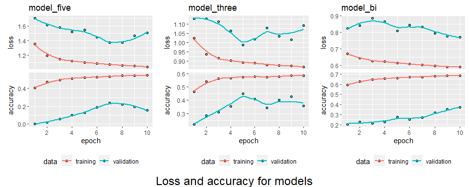

```r
plot_five <- plot(history_five)+
  theme(legend.position = "bottom")+
  ggtitle("model_five")

plot_three <- plot(history_three)+
  theme(legend.position = "bottom")+
  ggtitle("model_three")

plot_bi<- plot(history_bi)+
  theme(legend.position = "bottom")+
  ggtitle("model_bi")

library(ggpubr) #package that helps mixing multiple plots on the same page
plot <- ggarrange(plot_five, plot_three, plot_bi, ncol = 3)

annotate_figure(plot, bottom = text_grob("Loss and accuracy for models", size = 18))
```

## Evaluating on test data

```r
# 5 categories
result_five <- model_five %>% evaluate(x_test_five, y_test_five)
result_five <- as.data.frame(result_five)

# 5 categories
result_three <- model_three %>% evaluate(x_test_three, y_test_three)
# 5 categories
result_bi <- model_bi %>% evaluate(x_test_bi, y_test_bi)
```

```r
results <- cbind(result_five, result_three, result_bi)
results
```

|  | result_five | result_three | result_bi |
| --- | --- | --- | --- |
| loss | 1.3556485 | 0.9472877 | 0.6541355 |
| accuracy | 0.3409944 | 0.5396528 | 0.5983106 |

```r
class_pred_five <- model_five %>% predict(x_test_five)
class_pred_three <- model_three %>% predict(x_test_three)
class_pred_bi <- model_bi %>% predict(x_test_bi)
```

To get a more thorough look at the models ability to accurately predict the outcomes the accuracy of the models are calculated.

```r
# 5 categories
pred_collected_five <- tibble(
  truth = data_test_five %>% pull(y) %>% as.factor, #Takes the true values from the training data
  predicted_five = model_five %>% predict_classes(x_test_five)) %>%  #predicting y based on the training data
  pivot_longer(cols = -truth,
               names_to = 'model',
               values_to = '.pred')

pred_collected_five %<>%
  mutate(.pred = .pred + 1) %>%
  mutate(.pred = ifelse(.pred == 1, "Healthy",
                 ifelse(.pred == 2, "Hoof and limb disorders",
                 ifelse(.pred == 3, "Metabolic disorders",
                 ifelse(.pred == 4, "Reproduction disorders", "Udder disorders"))))) %>%
  mutate(.pred = .pred %>% as.factor())

# 3 categories
pred_collected_three <- tibble(
  truth = data_test_three %>% pull(y) %>% as.factor, #Takes the true values from the training data
  predicted_three = model_three %>% predict_classes(x_test_three)) %>%  #predicting y based on the training data
  pivot_longer(cols = -truth,
               names_to = 'model',
               values_to = '.pred')

pred_collected_three %<>%
  mutate(.pred = .pred + 1) %>%
  mutate(.pred = ifelse(.pred == 1, "Healthy",
                 ifelse(.pred == 2, "Other", "Udder disorders"))) %>%
  mutate(.pred = .pred %>% as.factor())

# 2 categories
pred_collected_bi <- tibble(
  truth = data_test_bi %>% pull(y) %>% as.factor, #Takes the true values from the training data
  predicted_bi = model_bi %>% predict_classes(x_test_bi)) %>%  #predicting y based on the training data
  pivot_longer(cols = -truth,
               names_to = 'model',
               values_to = '.pred')

pred_collected_bi %<>%
  mutate(.pred = .pred + 1) %>%
  mutate(.pred = ifelse(.pred == 1, "Healthy", "Sick")) %>%
  mutate(.pred = .pred %>% as.factor())
```

```r
# 5 categories
pred_five_truth <- pred_collected_five %>%
  count(truth)

pred_five_pred <- pred_collected_five %>%
  count(.pred)

pred_five <- cbind(pred_five_truth, pred_five_pred)
pred_five
```

| truth | n | .pred | n |
| --- | --- | --- | --- |
| Healthy | 695 | Healthy | 989 |
| Hoof and limb disorders | 194 | Hoof and limb disorders | 562 |
| Metabolic disorders | 83 | Metabolic disorders | 157 |
| Reproduction disorders | 153 | Reproduction disorders | 239 |
| Udder disorders | 1007 | Udder disorders | 185 |

```r
# 3 categories
pred_three_truth <- pred_collected_three %>%
  count(truth)

pred_three_pred <- pred_collected_three %>%
  count(.pred)

pred_three <- cbind(pred_three_truth, pred_three_pred)
pred_three
```

| truth | n | .pred | n |
| --- | --- | --- | --- |
| Healthy | 708 | Healthy | 1083 |
| Other | 373 | Other | 414 |
| Udder disorders | 1050 | Udder disorders | 634 |

```r
# 2 categories
pred_bi_truth <- pred_collected_bi %>%
  count(truth)

pred_bi_pred <- pred_collected_bi %>%
  count(.pred)

pred_bi <- cbind(pred_bi_truth, pred_bi_pred)
pred_bi
```

| truth | n | .pred | n |
| --- | --- | --- | --- |
| Healthy | 708 | Healthy | 1212 |
| Sick | 1423 | Sick | 919 |

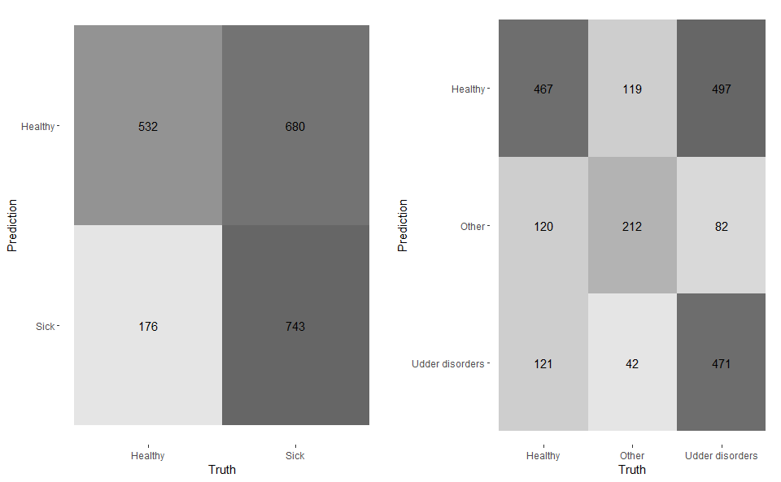

```r
#5 categories
cm_rf_five <- pred_collected_five %>% conf_mat(truth, .pred)
heatplotfive <- cm_rf_five %>% autoplot(type = "heatmap")

#5 categories
cm_rf_three <- pred_collected_three %>% conf_mat(truth, .pred)
heatplotthree <- cm_rf_three %>% autoplot(type = "heatmap")

#5 categories
cm_rf_bi <- pred_collected_bi %>% conf_mat(truth, .pred)
heatplotbi <- cm_rf_bi %>% autoplot(type = "heatmap")

ggarrange(heatplotbi, heatplotthree)
```

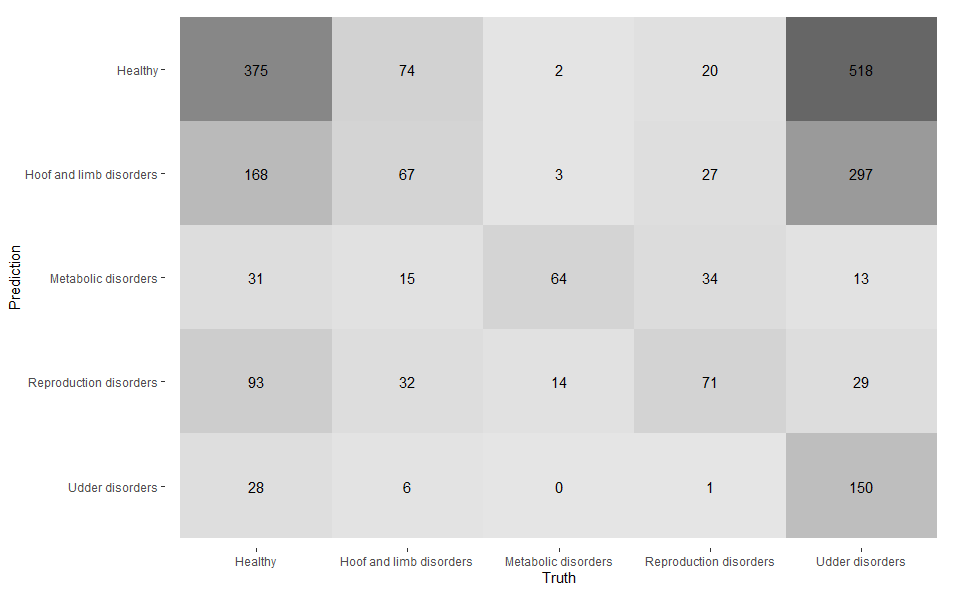

```r
heatplotfive
```

Since the overall accuracy can be misleading in cases with unbalanced classes the precision for each class in each of the categorizations is calculated.

```r
cm5 <- as.matrix(cm_rf_five$table)
cm3 <- as.matrix(cm_rf_three$table)
cm2 <- as.matrix(cm_rf_bi$table)
```

```r
rowsums5 = apply(cm5, 1, sum) #Number of predictions per class
colsums5 = apply(cm5, 2, sum) #Number of predictions per class
diag5 = diag(cm5) # Number of correctly classified instances per class

Precision5 = diag5/rowsums5 %>% as.table()
Sensitivity5 = diag5/colsums5 %>% as.table()

cbind(Precision5, Sensitivity5)
```

```
                        Precision5 Sensitivity5
Healthy                  0.3791709    0.5395683
Hoof and limb disorders  0.1192171    0.3453608
Metabolic disorders      0.4076433    0.7710843
Reproduction disorders   0.2970711    0.4640523
Udder disorders          0.8108108    0.1489573
```

```r
rowsums3 = apply(cm3, 1, sum)
colsums3 = apply(cm3, 2, sum) #Number of predictions per class
diag3 = diag(cm3)

Precision3 = diag3/rowsums3 %>% as.table()
Sensitivity3 = diag3/colsums3 %>% as.table()

cbind(Precision3, Sensitivity3)
```

```
                Precision3 Sensitivity3
Healthy          0.4312096    0.6596045
Other            0.5120773    0.5683646
Udder disorders  0.7429022    0.4485714
```

```r
rowsums2 = apply(cm2, 1, sum)
colsums2 = apply(cm2, 2, sum) #Number of predictions per class
diag2 = diag(cm2)

Precision2 = diag2/rowsums2 %>% as.table()
Sensitivity2 = diag2/colsums2 %>% as.table()

cbind(Precision2, Sensitivity2)
```

```
        Precision2 Sensitivity2
Healthy  0.4389439    0.7514124
Sick     0.8084875    0.5221363
```